# 1970s-2010s: How Has Music Changed Over the 6 Decades?

### c. Variation in the length of lyrics: by genre and time

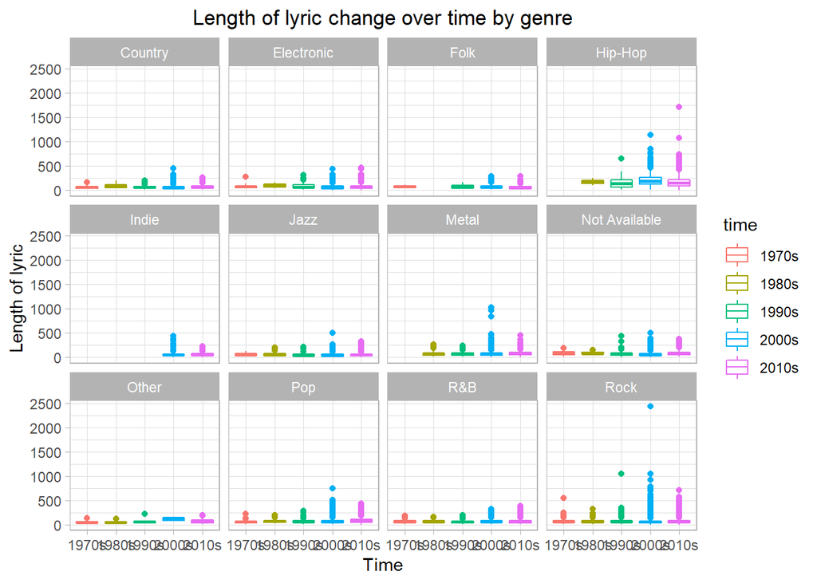

For most genre, the length of lyrics stay constant over time. More and more Hip-Hop, Metal, Pop and Rock music composers tend to write longer lyrics in some songs.

### d. Diveriity of word: in term of stemmed word

I use sina plot to depict the changes.

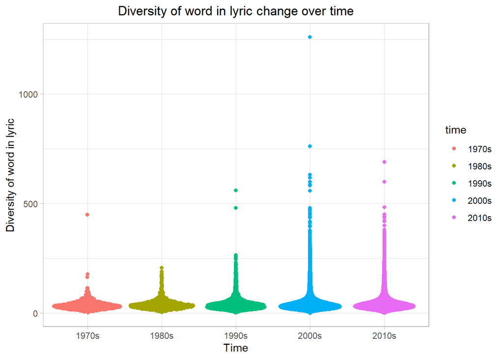

From the plot, we know that the overall diversity of word used in lyrics grows over time.

By genre,

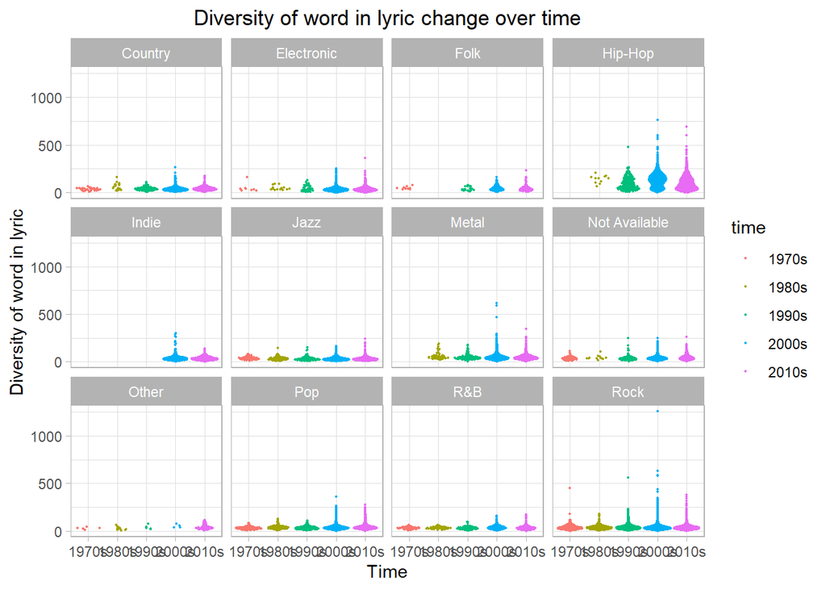

From the plot by differenrt genre, we can see that the growing diversity of word used in Hip-Hop music contribute to the overall growing diversity.

## 2. Word Frequency Variation: in terms of tf-idf

### a. Visualization: bar plots and wordcloud of popular words in terms of tf-idf per decade

### 1970s

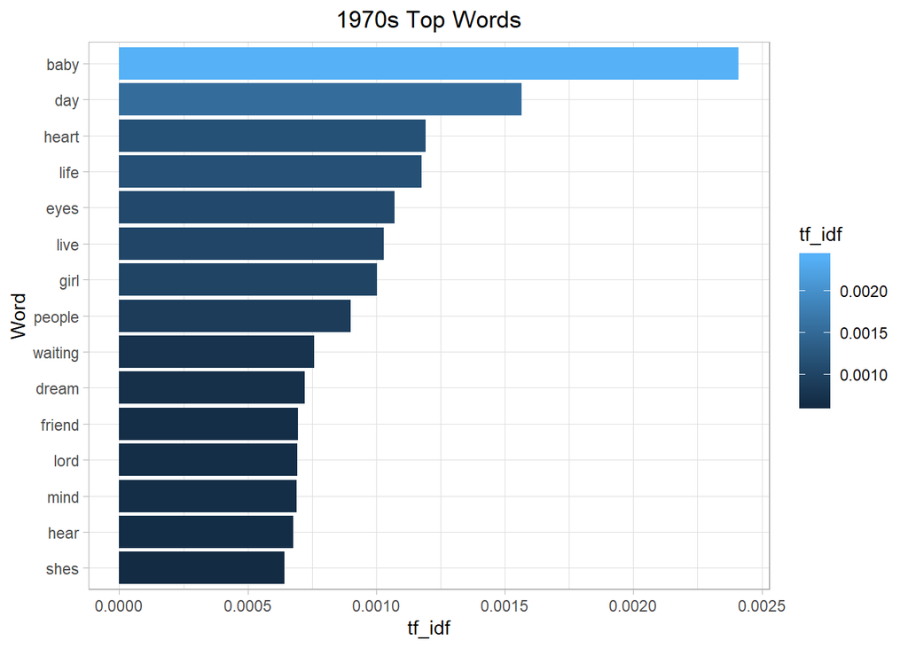

From the barplot we can see the most popular words seem to relate to love songs. Compared to other decades, the word “lord” may imply that, there may be quite a few songs related to religion or express prayer to lord.

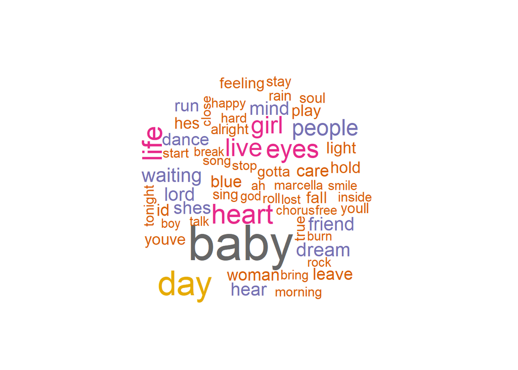

From the wordcloud we can infer, in 1970s, more lyrics of love songs may write to female, compared to male.

### 1980s

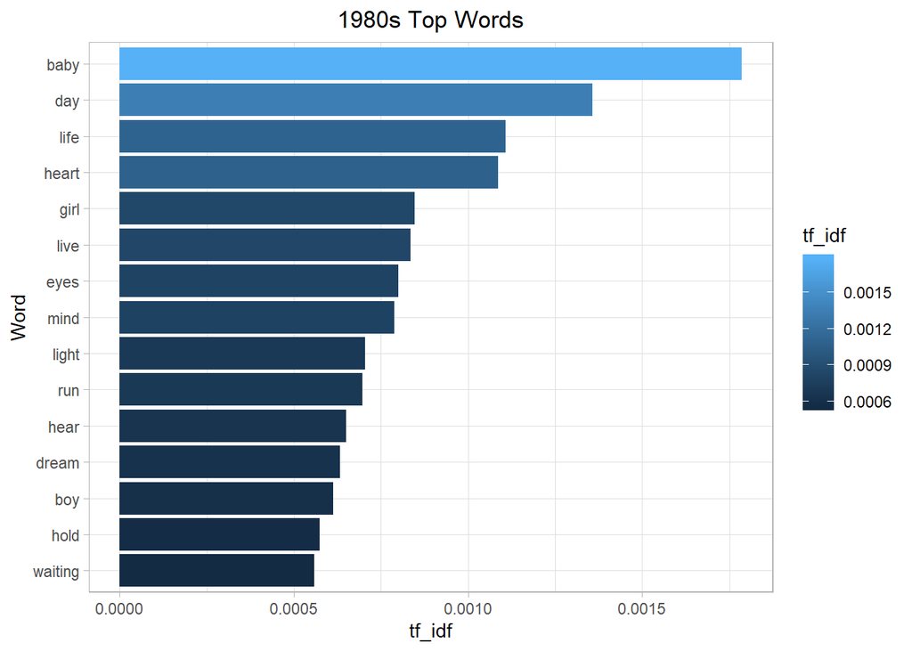

From the barplot, we can see that the popolar words almost remain the same, mostly related to love songs. The frequency of “boy” increased, which may imply that in 1980s, the proportion of songs written to boys may relatively high compared to other decades.

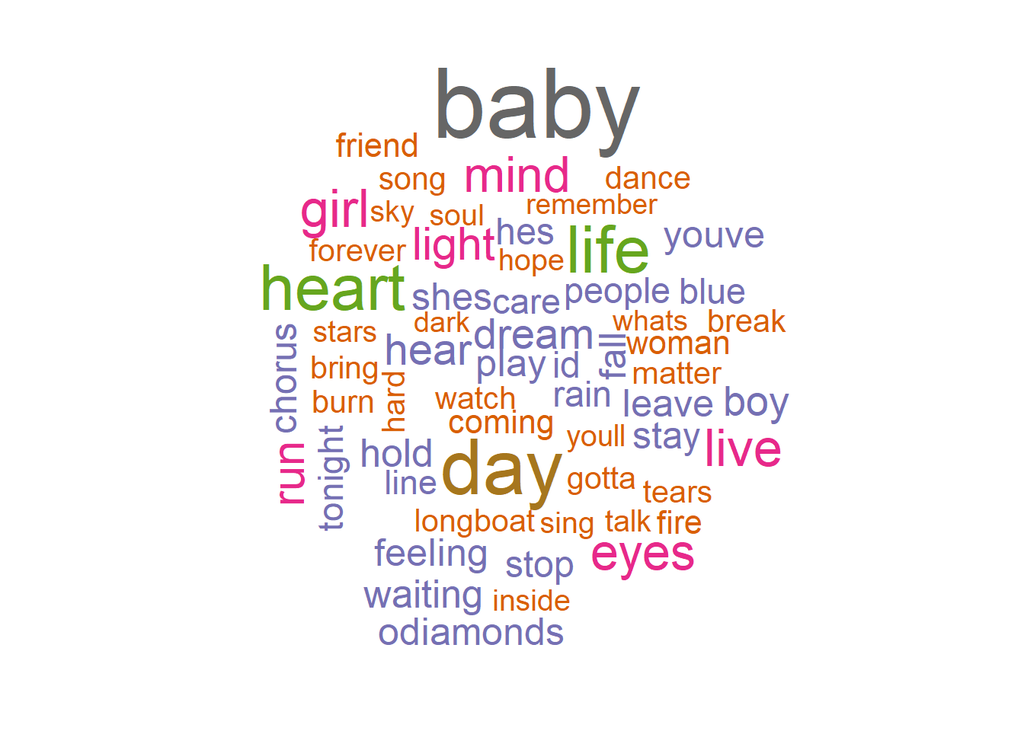

The wordcloud agrees with the finding of the barplot. Besides, compared to 1970s, people use less words like lord or soul and the more popular words in the lyric tends to be encouraging.

### 1990s

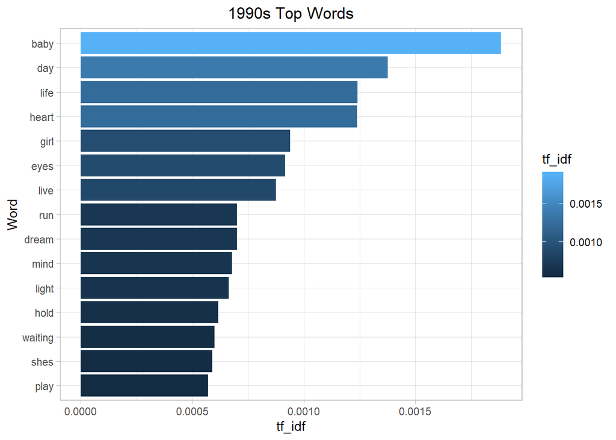

The barplot remains almost the same like 1980s.

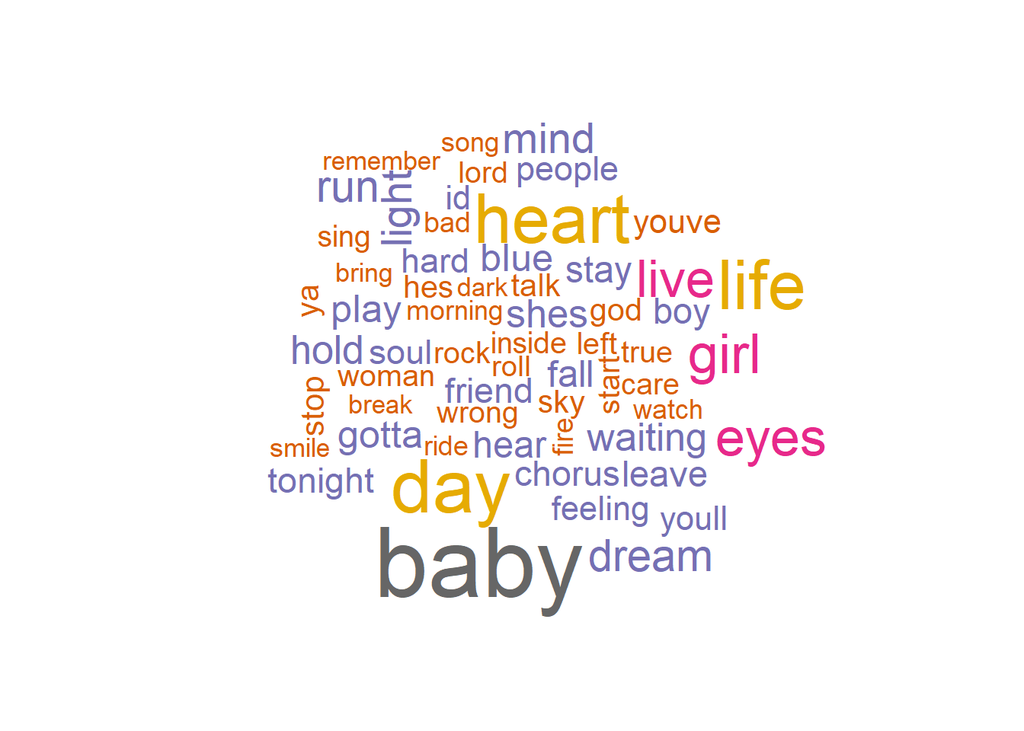

The wordcloud of 1990s is similar to the 1980s. We may conclude that the popular words in lyrics change a little in the two decades.

### 2000s

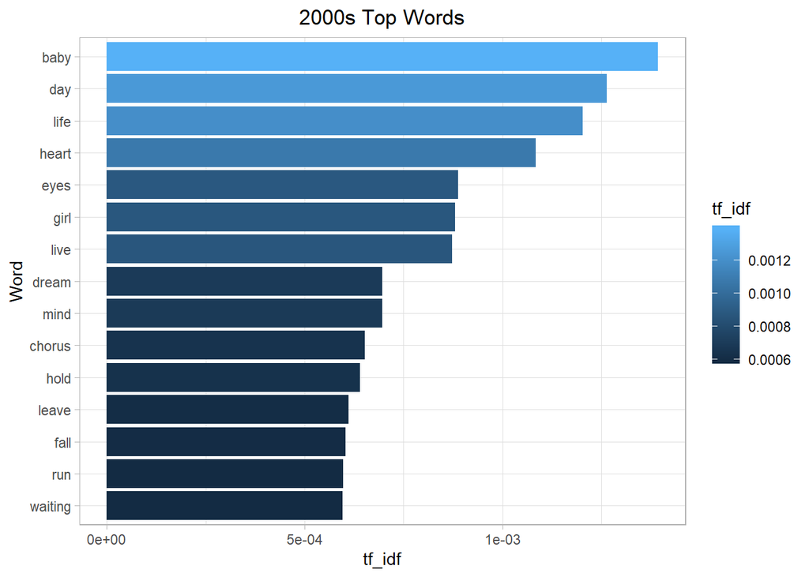

The barplot remains almost the same like 1980s and 1990s.

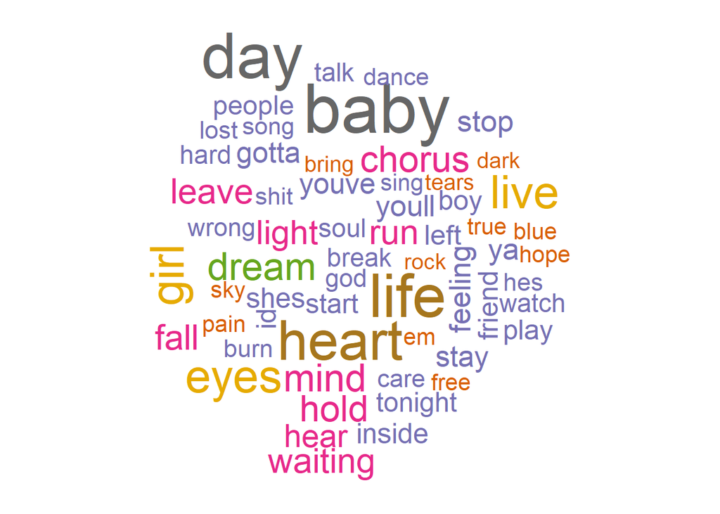

The wordcloud of 2000s is similar to the 1980s and 1990s. We may conclude that the popular words in lyrics change a little in the three decades.

### 2010s

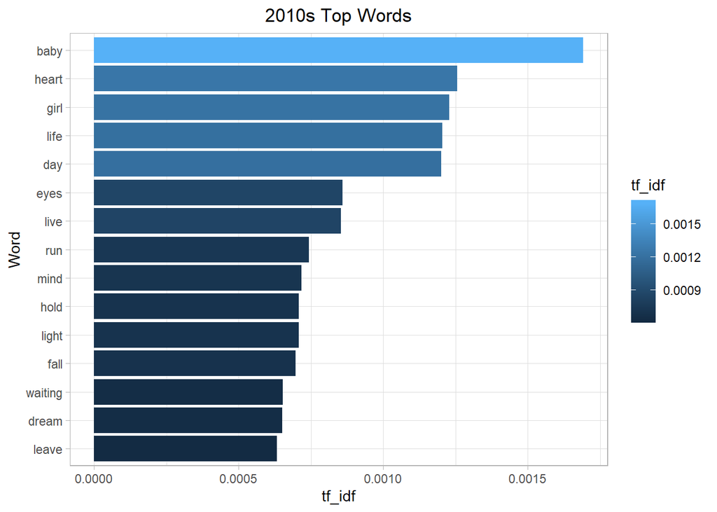

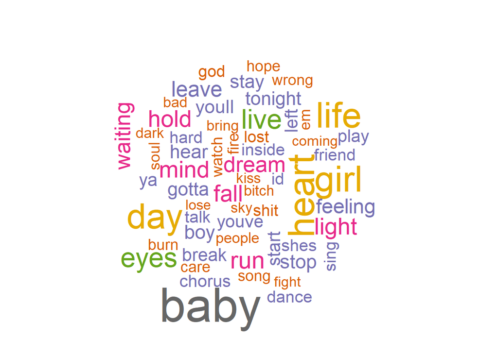

The wordcloud of 2010s is similar to the last 3 decades. We may conclude that the popular words in lyrics change a little in the four decades.

### b. Visulization with shiny_app

I built shiny_app to compare the difference of popular words in the lyric of different time and different genre. In the shiny_app, there are two tab panel: In the first tab panel, you can compare two bar plots of popular words in lyrics in any two decades (measured by tf_idf). In the second tab panel, you can compare two wordcloud of popular words in lyrics in any two decades and in any two genre, in terms of tf or tf_idf.

Shiny applications not supported in static R Markdown documents

Running the shiny-app, the popular words will change a lot with fixed decade and genre, if in terms of tf_idf. For example, in terms of tf, the most popular word in 1980s R&B lyrics is “love”, but in terms of tf_idf, it is “Jerome.”

## 3. Sentiment Analysis

### a. Proportion of positive and negative lyrics per decade: with bing

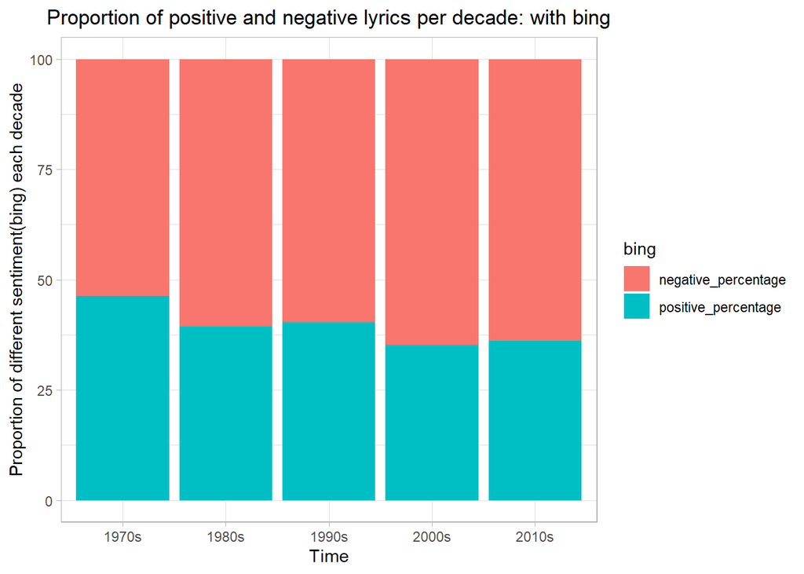

From this plot, we can see that the overall proportion of positive lyrics has decreased and the overall proportion of negative lyrics has increased.

### b. Proportion of positive and negative lyrics per decade: with nrc

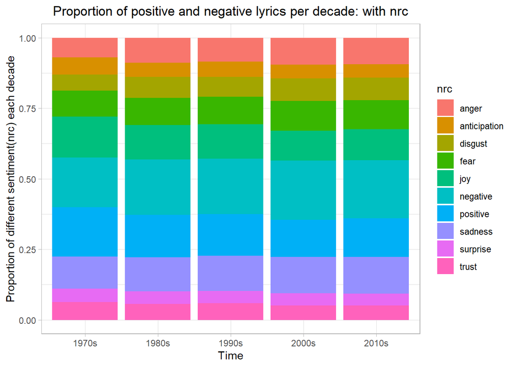

From this plot, we can see that the proportion of different sentiments defined by nrc has stayed relatively stable in these decades. The proportion of positive lyrics defined by nrc slightly decreased and the proportion of negative lyrics defined by nrc slightly increased.

### c. Proportion of positive and negative lyrics per decade: with nrc, by genre

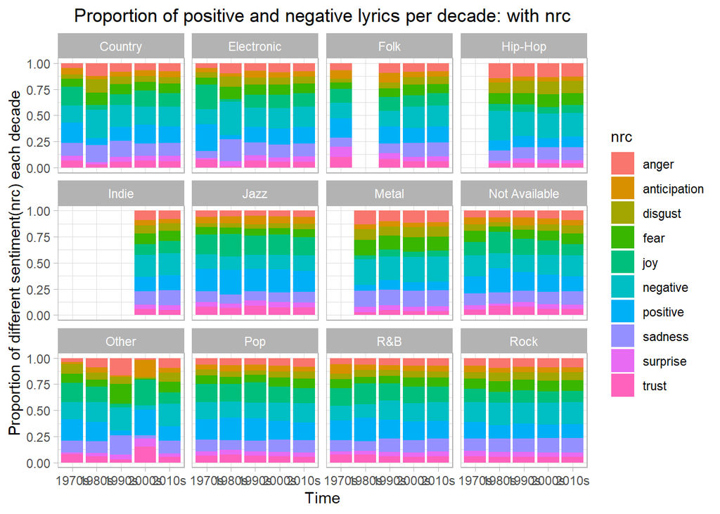

From the plot, we can see that: Country music: in 1980s, nearly 50% of the lyrics expressed disguts and negative emotion; Electronic music: in 1980s, the proportion of negative and surprise lyrics are relatively high compared to the proportion in other decades; Hip-Hop music: the proportion of negative lyrics has decreased over time; Metal music: the proportion of angry and negative lyrics has decreased over time.